# Kupferkanne RFM – Exploratory Data Analysis

Author

Ryszard Twardy

Published

July 14, 2026

Modified

October 24, 2026

Next: the win-back exhibits; the code is in the [repository on GitHub](https://github.com/ryszard-twardy/rfm-customer-segmentation-kupferkanne).

## Introduction

This notebook is the narrative companion to the eight SQL EDA views in `sql/02_eda_kupferkanne_2026.sql`. The split is deliberate: the views hold the queryable, reproducible definitions; this document holds the reasoning built on them – what the distributions look like, what was concluded, and how those conclusions shaped the RFM transformation design ([ADR 0009](https://github.com/ryszard-twardy/rfm-customer-segmentation-kupferkanne/blob/main/docs/adr/0009-analytical-notebook-with-quarto.md)). Because the pipeline runs EDA *between* validation and transformation ([ADR 0003](https://github.com/ryszard-twardy/rfm-customer-segmentation-kupferkanne/blob/main/docs/adr/0003-pipeline-order-eda-before-transform.md)), every finding below preceded the segmentation design rather than justifying it after the fact.

Each section follows the same shape: one distribution, one observation, and the design decision that observation drove. A footer on every section maps the finding to its ADR, its dashboard page, and its DAX measure family.

The segment follow-up, three win-back exhibits on the At Risk and Hibernating discounts, is on the win-back exhibits page.

**Synthetic-data disclosure.** The dataset is generated by synth-datagen with intentional, documented quality issues (duplicate line items, cents-format inconsistency, malformed dates, missing values, whitespace-padded keys – see [ADR 0008](https://github.com/ryszard-twardy/rfm-customer-segmentation-kupferkanne/blob/main/docs/adr/0008-synthetic-data-with-realistic-quality-issues.md)). The findings illustrate the method on realistic data; they are not market insight about any real business.

**TipTL;DR – four findings**

- **The top 20% of customers generate 71% of revenue** (the top decile alone carries 53%) – value-based segmentation is justified before a single segment is built.
- **Order values are hard right-skewed** (median EUR 35 vs mean EUR 50; 1,688 orders sit beyond the P99 of EUR 264, the largest at 3.8 times it) – Monetary scoring must be quantile-based, not mean-based.
- **Only 26% of customers are single-order** – the Frequency dimension varies enough to score, but its quintiles do not separate cleanly: 5,842 customers share an order count with a customer scored in another quintile.
- **Germany carries 57% of revenue while average order value is flat (EUR 50 +/- 3%) across all nine markets** – market size, not basket economics, differentiates countries.

### Reconciliation against the KPI baseline

Before trusting any chart below, the notebook proves it reads the same universe as the dashboard and the KPI parity harness (`harness/`). Totals are derived read-only from `sales_curated`; the population split across the EDA views is stated and quantified, not assumed.

```python
import logging
import re
from pathlib import Path

import matplotlib.pyplot as plt
import pandas as pd
import yaml
from decimal import Decimal
from google.cloud import bigquery
from IPython.display import HTML
from matplotlib.ticker import FuncFormatter

PROJECT = "kupferkanne-2026"
DATASET = f"{PROJECT}.sales"
ACCENT = "#4A7AA0"
MUTED = "#C8CDD3"

client = bigquery.Client(project=PROJECT)


def view(name: str) -> pd.DataFrame:
    """Read one EDA view into a DataFrame (read-only SELECT)."""
    sql = f"SELECT * FROM `{DATASET}.{name}`"
    return client.query(sql, location="EU").to_dataframe()


LABELS = {
    "recency_bucket": "Recency Bucket", "customer_count": "Customers",
    "min_days": "Min Days", "max_days": "Max Days", "order_id": "Order ID",
    "country": "Country", "order_value": "Order Value",
    "p99_threshold": "P99 Threshold", "multiple_of_p99": "Multiple of P99",
    "order_count": "Orders", "avg_order_value": "Avg Order Value",
    "total_revenue": "Total Revenue", "revenue_share_pct": "Revenue Share",
    "line_count": "Line Items", "avg_items_per_order": "Avg Items per Order",
    "avg_declared_items_per_order": "Avg Declared Items per Order",
    "declared_actual_mismatch_count": "Declared vs Actual Mismatch Count",
    "declared_actual_mismatch_pct": "Declared vs Actual Mismatch",
}


NUMERIC_CELL = re.compile(r"-?[\d,]*\.?\d+%?")


def show(df, labels=LABELS, percent=(), currency_int=(), ratio=()):
    """HTML table, no index. Formats integer cols with thousands separators and
    float/Decimal cols (percent -> N.NN%, currency_int -> whole with thousands,
    ratio -> plain 2dp, else 2dp with thousands), then renames headers via
    `labels`. Header and cells carry their column's kind for the page styles:
    col-num when every cell is a plain number or percentage, else col-text."""
    out = df.copy()
    for col in out.columns:
        s = out[col]
        is_num = pd.api.types.is_float_dtype(s) or (
            s.dtype == object and s.map(lambda v: isinstance(v, Decimal)).any()
        )
        if pd.api.types.is_integer_dtype(s):
            out[col] = s.map(lambda v: f"{int(v):,}" if pd.notna(v) else "")
        elif col in percent:
            out[col] = s.map(lambda v: f"{float(v):.2f}%" if pd.notna(v) else "")
        elif col in currency_int:
            out[col] = s.map(lambda v: f"{float(v):,.0f}" if pd.notna(v) else "")
        elif col in ratio:
            out[col] = s.map(lambda v: f"{float(v):.2f}" if pd.notna(v) else "")
        elif is_num:
            out[col] = s.map(lambda v: f"{float(v):,.2f}" if pd.notna(v) else "")
    kinds = ["col-num" if out[col].map(lambda v: bool(NUMERIC_CELL.fullmatch(str(v)))).all()
             else "col-text" for col in out.columns]
    table = out.rename(columns=labels).to_html(index=False)

    def mark(row):
        assert len(re.findall(r"<t[hd][ >]", row[0])) == len(kinds), row[0]
        cells = iter(kinds)
        return re.sub(r"<t([hd])>", lambda m: f'<t{m[1]} class="{next(cells)}">', row[0])

    return HTML(re.sub(r"<tr[^>]*>.*?</tr>", mark, table, flags=re.S))


# Charts use the brand type stack from _brand.yml, as the win-back exhibits do.
# Lato heads the stack; mute matplotlib's per-text warning when it is
# not installed.
brand = yaml.safe_load(Path("_brand.yml").read_text(encoding="utf-8"))
FONT_STACK = [f.strip() for f in brand["typography"]["base"]["family"].split(",")]
LABEL_TEXT = brand["color"]["palette"]["label_text"]  # muted text, 4.5:1 on the page surfaces
logging.getLogger("matplotlib.font_manager").setLevel(logging.ERROR)

plt.rcParams.update({
    "font.family": FONT_STACK,
    "font.sans-serif": [f for f in FONT_STACK if f != "sans-serif"],
    "figure.figsize": (8, 3.5),
    "axes.spines.top": False,
    "axes.spines.right": False,
    "axes.grid": True,
    "axes.grid.axis": "y",
    "grid.alpha": 0.3,
})
```

```python
BASELINE = {"Revenue": 8_476_200.74, "Orders": 168_777, "Customers": 14_967}

cur = client.query(
    f"""
    SELECT
        ROUND(SUM(order_value), 2) AS revenue,
        COUNT(*) AS orders,
        COUNT(DISTINCT customer_id) AS customers
    FROM `{DATASET}.sales_curated`
    """,
    location="EU",
).to_dataframe().iloc[0]

derived = {
    "Revenue": round(float(cur["revenue"]), 2),
    "Orders": int(cur["orders"]),
    "Customers": int(cur["customers"]),
}

dist_orders = int(view("eda_order_value_distribution")["order_count"].iloc[0])
basket_orders = int(view("eda_basket_composition")["order_count"].sum())

recon = pd.DataFrame({
    "Metric": list(BASELINE),
    "KPI baseline": [f"{v:,.2f}" if isinstance(v, float) else f"{v:,}"
                     for v in BASELINE.values()],
    "Derived (sales_curated)": [f"{v:,.2f}" if isinstance(v, float)
                                else f"{v:,}" for v in derived.values()],
    "Match": ["yes" if BASELINE[k] == derived[k] else "NO"
              for k in BASELINE],
})
show(recon)
```

Table 1: Headline totals derived read-only from sales_curated against the KPI baseline.

| Metric | KPI baseline | Derived (sales_curated) | Match |
| --- | --- | --- | --- |
| Revenue | 8,476,200.74 | 8,476,200.74 | yes |
| Orders | 168,777 | 168,777 | yes |
| Customers | 14,967 | 14,967 | yes |

```python
split = pd.DataFrame({
    "Population": [
        "Item-bearing orders (order-value views, INNER JOIN – matches sales_curated)",
        "All validated orders (eda_basket_composition, LEFT JOIN)",
        "Delta: itemless orders (explained, not an error)",
    ],
    "Orders": [f"{dist_orders:,}", f"{basket_orders:,}",
               f"{basket_orders - dist_orders:,}"],
})
show(split)
```

Table 2: Order populations behind the EDA views: item-bearing orders against all validated orders.

| Population | Orders |
| --- | --- |
| Item-bearing orders (order-value views, INNER JOIN – matches sales_curated) | 168,777 |
| All validated orders (eda_basket_composition, LEFT JOIN) | 169,181 |
| Delta: itemless orders (explained, not an error) | 404 |

The three headline totals match the baseline exactly. The population split is the one reconciliation line that needs explaining: order-value views cover the **168,777** item-bearing orders (INNER JOIN to item lines, the same population as `sales_curated`), while the basket-composition view keeps all **169,181** validated orders visible (LEFT JOIN) – the **404** itemless orders are a seeded data-quality artifact examined in the Data quality section. A related consequence: customer-grain views (frequency, recency) count 14,975 customers, eight more than curated – those eight exist only through itemless orders.

## Recency

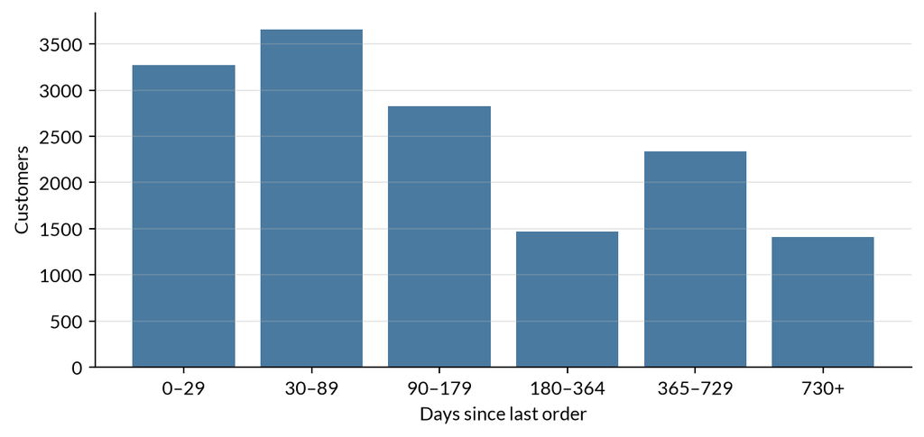

Figure 1: Customers by recency bucket, anchored on MAX(order_date) = the dataset's last order day.

```python
rec = view("eda_recency_distribution").sort_values("recency_bucket")
rec["customer_count"] = rec["customer_count"].astype(int)
# Readable bucket labels from each bucket's observed day range; the last bucket
# is open-ended. The view keeps its bucket codes.
last = rec["min_days"].max()
rec["days"] = [f"{lo:,}+" if lo == last else f"{lo:,}–{hi:,}"
               for lo, hi in zip(rec["min_days"], rec["max_days"])]

fig, ax = plt.subplots()
ax.bar(rec["days"], rec["customer_count"], color=ACCENT)
ax.set_ylabel("Customers")
ax.set_xlabel("Days since last order")
fig.canvas.draw()
boxes = [t.get_window_extent() for t in ax.get_xticklabels()]
assert not any(a.overlaps(b) for i, a in enumerate(boxes) for b in boxes[i + 1:]), "tick labels overlap"
plt.show()
```

```python
show(rec[["days", "customer_count", "min_days", "max_days", "recency_bucket"]],
     labels={**LABELS, "days": "Days since last order", "recency_bucket": "View bucket code"})
```

Table 3: Customers by recency bucket, with each bucket's observed day range and its code in the recency view.

| Days since last order | Customers | Min Days | Max Days | View bucket code |
| --- | --- | --- | --- | --- |
| 0–29 | 3,273 | 0 | 29 | 01_active_30d |
| 30–89 | 3,655 | 30 | 89 | 02_recent_90d |
| 90–179 | 2,827 | 90 | 179 | 03_warming_180d |
| 180–364 | 1,472 | 180 | 364 | 04_cooling_365d |
| 365–729 | 2,335 | 365 | 729 | 05_cold_2y |
| 730+ | 1,413 | 730 | 1,162 | 06_dormant_2y_plus |

The dataset ends in March 2026, so anchoring recency on `CURRENT_DATE()` would add the same growing offset to every customer and compress the distribution's low end into meaninglessness. Anchored on `MAX(order_date)` instead, the spread is real and analytically useful: 3,273 customers ordered within 30 days of the anchor, 6,928 within 90 days, and a long cold tail remains – 2,335 customers between one and two years out, plus 1,413 dormant beyond two years. That spread is what makes a Recency quintile worth computing: NTILE(5) boundaries land on genuinely different behaviours rather than slicing noise. The anchor decision was validated here before the RFM pipeline hard-coded it. The bucket edges (30/90/180/365/730 days) also prefigure the dashboard's recency bands used in churn analysis.

*Where this lands:* ADR 0006; Page 4 Churn Risk & What-If; Folder 04 – Time Intelligence (Recency Buckets).

## Frequency

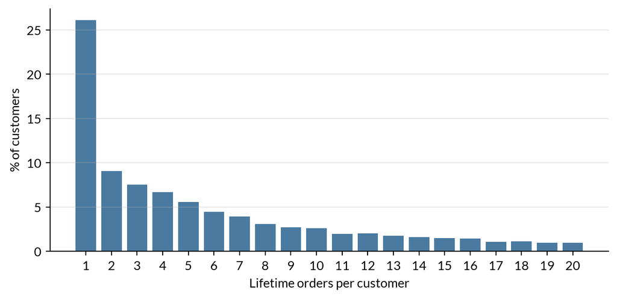

Figure 2: Share of customers by lifetime order count (axis truncated at 20; the tail runs to 174 orders per customer).

```python
freq = view("eda_customer_frequency_distribution").sort_values("order_count")
head = freq[freq["order_count"] <= 20].copy()
head["pct_of_customers"] = head["pct_of_customers"].astype(float)

fig, ax = plt.subplots()
ax.bar(head["order_count"].astype(int), head["pct_of_customers"], color=ACCENT)
ax.set_ylabel("% of customers")
ax.set_xlabel("Lifetime orders per customer")
ax.set_xticks(range(1, 21))
plt.show()
```

The failure mode this view exists to catch: if 80%+ of customers had exactly one order, a Frequency quintile would be noise – four of five score bands would slice a single behaviour. That did not materialise. Single-order customers are 26.1% of the base; a customer at the median has roughly four to five lifetime orders, and the tail stretches to 174 orders. With that spread, Frequency varies across the base, but NTILE(5) does not separate the bottom cleanly: one-order customers fill the first quintile and 913 more sit in the second, so one-order behaviour spans the two lowest bands. The spread still kept Frequency as a full scoring dimension in the RFM design instead of collapsing it into a binary repeat-buyer flag – an option that would have been correct under the 80% failure mode and wrong here.

*Where this lands:* ADR 0006; Page 2 Segment Deep Dive; Folder 02 – RFM Scores.

## Monetary

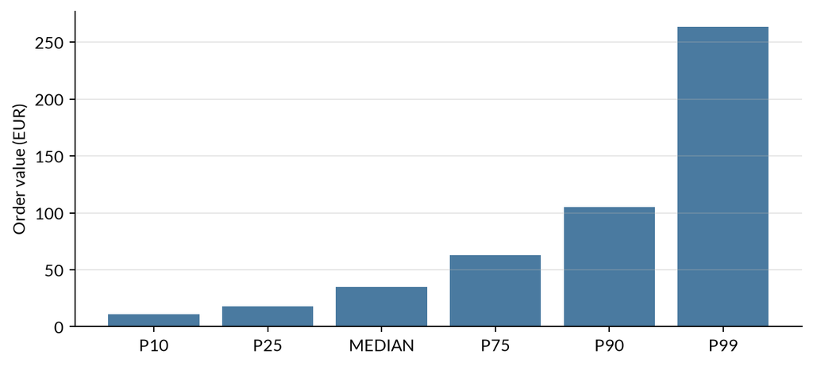

Figure 3: Order-value percentiles (EUR). The gap between P90 and P99 is the long tail.

```python
dist = view("eda_order_value_distribution").iloc[0]
pct_labels = ["p10", "p25", "median", "p75", "p90", "p99"]
pct_values = [float(dist[c]) for c in pct_labels]

fig, ax = plt.subplots()
ax.bar([p.upper() for p in pct_labels], pct_values, color=ACCENT)
ax.set_ylabel("Order value (EUR)")
plt.show()
```

```python
out = view("eda_order_value_outliers")
out = out.sort_values("order_value", ascending=False).head(5)
show(out[["order_id", "country", "order_value", "p99_threshold", "multiple_of_p99"]], ratio=["multiple_of_p99"])
```

Table 4: The five largest orders, each with the P99 order-value threshold and its multiple of it.

| Order ID | Country | Order Value | P99 Threshold | Multiple of P99 |
| --- | --- | --- | --- | --- |
| ORD-2023-041902 | DE | 997.23 | 263.70 | 3.78 |
| ORD-2025-052745 | DE | 657.98 | 263.70 | 2.50 |
| ORD-2025-055411 | DE | 646.20 | 263.70 | 2.45 |
| ORD-2024-047627 | UK | 644.16 | 263.70 | 2.44 |
| ORD-2024-048602 | DE | 622.75 | 263.70 | 2.36 |

The shape is hard right-skew: median EUR 35.01 against a mean of EUR 50.22, P90 at EUR 105 and P99 at EUR 263.70, with a maximum of EUR 997.23 – 3.8 times the P99 threshold. 1,688 orders (about 1%) sit beyond P99. Inspected, the tail reads as legitimate high-value or B2B-style baskets rather than artifacts: values are plausible multiples, spread across markets, and the cents-format errors that would fake such a tail were already normalised in cleaning. Two consequences: Monetary scoring must be quantile-based (a mean-anchored split would put the boundary above 60% of orders), and the whales must stay in – they are exactly whom the Champions segment exists to identify. Order value here is the curated expression verbatim – `ROUND(SUM(line_net_amount), 2)` per order, items INNER JOINed, with the order discount already inside the line net amounts rather than applied again – so every figure reconciles with `sales_curated`.

*Where this lands:* ADR 0006; Page 2 Segment Deep Dive; Folder 02 – RFM Scores.

## Temporal pattern

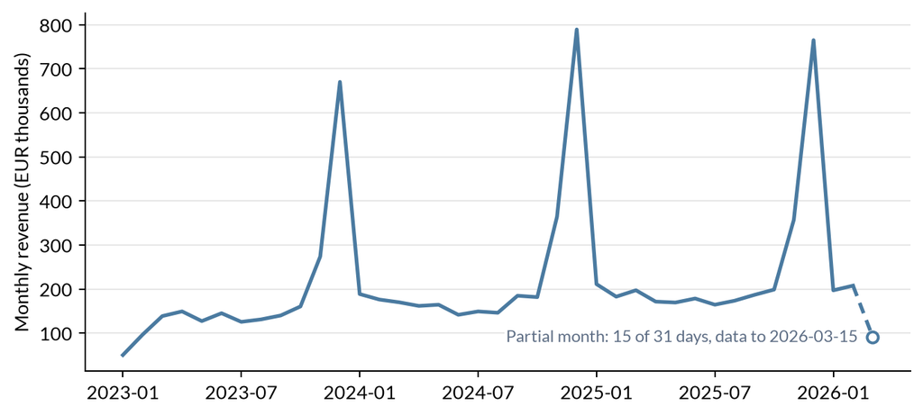

Figure 4: Monthly revenue, January 2023 to March 2026 (39 months; final month truncated at the data cutoff).

```python
mon = view("eda_monthly_temporal_pattern").sort_values("year_month").reset_index(drop=True)
mon["monthly_revenue"] = mon["monthly_revenue"].astype(float)
# Days each month covers, from the view's own population: validated orders with item lines.
span = client.query(
    f"""
    SELECT MIN(o.order_date) AS first_day, MAX(o.order_date) AS last_day
    FROM `{DATASET}.stg_orders_validated` AS o
    WHERE EXISTS (
        SELECT 1 FROM `{DATASET}.stg_items_validated` AS i WHERE i.order_id = o.order_id
    )
    """,
    location="EU",
).to_dataframe().iloc[0]
first_day, last_day = pd.Timestamp(span["first_day"]), pd.Timestamp(span["last_day"])
month_start = pd.to_datetime(mon["year_month"] + "-01")
month_end = month_start + pd.offsets.MonthEnd(0)
mon["days_in_month"] = month_end.dt.day
mon["days_covered"] = (month_end.clip(upper=last_day) - month_start.clip(lower=first_day)).dt.days + 1
assert len(mon) == (last_day.year - first_day.year) * 12 + last_day.month - first_day.month + 1
partial = mon.index[mon["days_covered"] < mon["days_in_month"]]
assert set(partial) <= {0, len(mon) - 1}, partial  # only the panel's edges can be cut

# Full months as a solid line; a partial month is reached by a dashed segment, drawn as an
# open marker and labelled with the days it covers and the data edge that cuts it.
fig, ax = plt.subplots()
full = mon.drop(index=partial)
ax.plot(full.index, full["monthly_revenue"], color=ACCENT, linewidth=2)
for i in partial:
    j = i + 1 if i == 0 else i - 1
    edge = first_day if i == 0 else last_day
    ax.plot([j, i], mon.loc[[j, i], "monthly_revenue"], color=ACCENT,
            linewidth=2, linestyle=(0, (3, 2)))
    ax.plot([i], mon.loc[[i], "monthly_revenue"], linestyle="none",
            marker="o", markersize=6, markerfacecolor="white", markeredgecolor=ACCENT,
            markeredgewidth=1.5, zorder=3)
    ax.annotate(
        f"Partial month: {mon.at[i, 'days_covered']} of {mon.at[i, 'days_in_month']} days, "
        f"data {'from' if i == 0 else 'to'} {edge:%Y-%m-%d}",
        (i, mon.at[i, "monthly_revenue"]),
        xytext=(8 if i == 0 else -8, 0), textcoords="offset points",
        ha="left" if i == 0 else "right", va="center", fontsize=9, color=LABEL_TEXT,
        bbox=dict(facecolor="white", edgecolor="none", pad=1),
    )
ax.set_ylabel("Monthly revenue (EUR thousands)")
ax.yaxis.set_major_formatter(FuncFormatter(lambda v, _: f"{v / 1000:,.0f}"))
ax.set_xticks(mon.index[::6], mon["year_month"][::6])
plt.show()
```

Thirty-nine months, three regimes. A 2023 ramp-up as the synthetic customer base accumulates; a mature phase with pronounced December peaks (the maximum, EUR 789K, lands in December 2024); and a final month visibly truncated – March 2026 stops mid-month at the data cutoff. None of this is a market finding (the seasonality is generator-encoded), but two analytical handling decisions hang on it. First, the bounded panel is precisely why recency is anchored on `MAX(order_date)`: the dataset's "now" is March 2026, not the render date. Second, the truncated final month is a known hazard for any month-over-month comparison downstream – the dashboard's time series inherits it, and a naive last-month delta would read as a collapse. The gaps check also passes: all 39 calendar months are present, so temporal coverage is continuous.

*Where this lands:* ADR 0006 (anchor); Page 1 Executive Summary; Folder 01 – Core KPIs.

## Geography

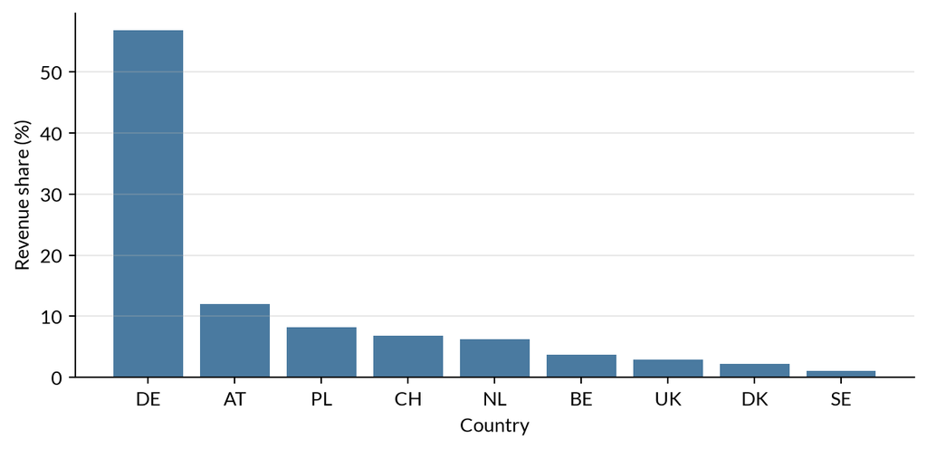

Figure 5: Revenue share by customer country (customer-grain attribution, matching sales_curated).

```python
geo = view("eda_country_breakdown").sort_values("total_revenue",
                                                ascending=False)
geo["revenue_share_pct"] = geo["revenue_share_pct"].astype(float)

fig, ax = plt.subplots()
ax.bar(geo["country"], geo["revenue_share_pct"], color=ACCENT)
ax.set_ylabel("Revenue share (%)")
ax.set_xlabel("Country")
plt.show()
```

```python
show(geo[["country", "order_count", "customer_count", "avg_order_value",
     "total_revenue", "revenue_share_pct"]], currency_int=["total_revenue"], percent=["revenue_share_pct"])
```

Table 5: Orders, customers, average order value and revenue by customer country.

| Country | Orders | Customers | Avg Order Value | Total Revenue | Revenue Share |
| --- | --- | --- | --- | --- | --- |
| DE | 95,959 | 8,347 | 50.17 | 4,813,866 | 56.79% |
| AT | 20,167 | 1,798 | 50.51 | 1,018,628 | 12.02% |
| PL | 13,687 | 1,217 | 50.62 | 692,871 | 8.17% |
| CH | 11,372 | 1,025 | 50.52 | 574,556 | 6.78% |
| NL | 10,713 | 1,052 | 49.75 | 533,007 | 6.29% |
| BE | 6,355 | 610 | 49.79 | 316,426 | 3.73% |
| UK | 5,045 | 458 | 49.57 | 250,069 | 2.95% |
| DK | 3,790 | 313 | 50.11 | 189,913 | 2.24% |
| SE | 1,689 | 147 | 51.43 | 86,866 | 1.02% |

Germany dominates with 56.8% of revenue; the top three markets (DE, AT, PL) carry 77%. The more interesting observation is what does *not* vary: average order value sits in a band from EUR 49.57 (UK) to EUR 51.43 (SE) – under 4% spread across nine markets. Market differences are volume differences, not basket-economics differences, which means country is a scale attribute for segmentation, not a behavioural one – RFM scores need no per-country normalisation. One semantic note inherited from the curated layer: country is the *customer's* country (joined from `v_dim_customers_std` at customer grain), not a shipping attribute of the order, and customers with no country on the dimension would surface as NULL rather than being relabelled.

*Where this lands:* ADR 0014 (Deneb regional map); Page 6 Regional Analysis; Folder 06 – Formatting & Regional.

## Concentration

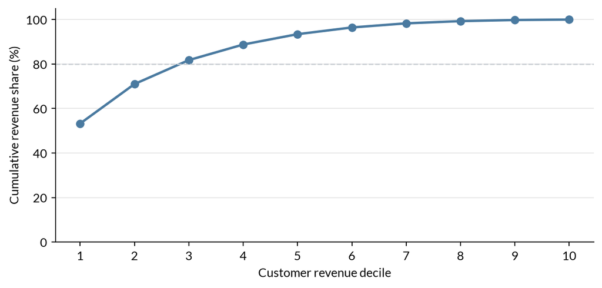

Figure 6: Cumulative revenue share by customer revenue decile (decile 1 = highest-spending 10%).

```python
par = view("eda_pareto_concentration").sort_values("revenue_decile")
par["pct_of_total_revenue"] = par["pct_of_total_revenue"].astype(float)
cum = par["pct_of_total_revenue"].cumsum()

fig, ax = plt.subplots()
ax.plot(par["revenue_decile"].astype(int), cum, color=ACCENT, linewidth=2,
        marker="o")
ax.axhline(80, color=MUTED, linestyle="--", linewidth=1)
ax.set_ylabel("Cumulative revenue share (%)")
ax.set_xlabel("Customer revenue decile")
ax.set_xticks(range(1, 11))
ax.set_ylim(0, 105)
plt.show()
```

The top decile of customers generates 53.3% of revenue; the top two deciles together, 71.0%. The canonical 80/20 rule does not quite hold – the top 20% carry 71%, and reaching 80% takes the top three deciles – but the strategic conclusion survives the nuance: revenue concentration is steep enough that value-tiered treatment (retention spend on Champions, win-back on high-value At Risk) is justified, while the curve is shallow enough that the bottom half is not economically irrelevant (it still carries about 7%). This view validated the segmentation *ex ante*, before any segment existed; the dashboard's revenue-concentration chart on Page 5 monitors the same curve *ex post*, per segment, as the data evolves. The two are complements, not duplicates.

*Where this lands:* ADR 0006; Page 5 Customer Lifecycle Intelligence (Revenue Concentration / Pareto); Folder 03 – Segment Analysis.

## Data quality

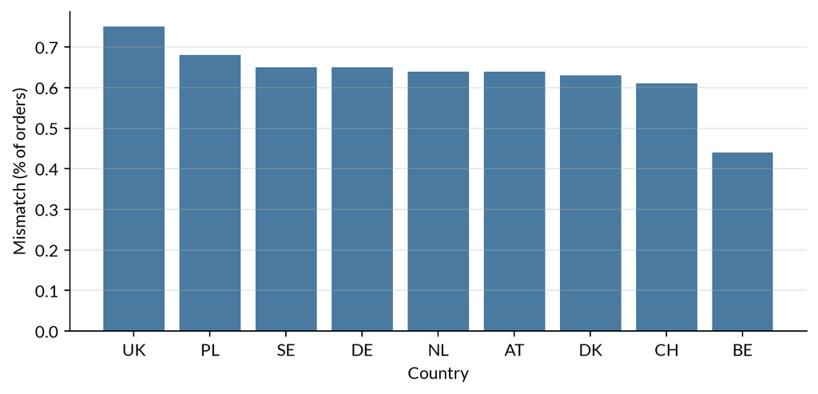

Figure 7: Share of orders whose declared basket size disagrees with the actual item-line count, by country.

```python
bas = view("eda_basket_composition").sort_values(
    "declared_actual_mismatch_pct", ascending=False)
bas["declared_actual_mismatch_pct"] = (
    bas["declared_actual_mismatch_pct"].astype(float))

fig, ax = plt.subplots()
ax.bar(bas["country"], bas["declared_actual_mismatch_pct"], color=ACCENT)
ax.set_ylabel("Mismatch (% of orders)")
ax.set_xlabel("Country")
plt.show()
```

```python
show(bas[["country", "order_count", "line_count", "avg_items_per_order",
     "avg_declared_items_per_order", "declared_actual_mismatch_count",
     "declared_actual_mismatch_pct"]], percent=["declared_actual_mismatch_pct"])
```

Table 6: Declared against actual basket size by country, with the mismatch count and rate.

| Country | Orders | Line Items | Avg Items per Order | Avg Declared Items per Order | Declared vs Actual Mismatch Count | Declared vs Actual Mismatch |
| --- | --- | --- | --- | --- | --- | --- |
| UK | 5,055 | 8,099 | 1.60 | 1.61 | 38 | 0.75% |
| PL | 13,721 | 22,112 | 1.61 | 1.62 | 93 | 0.68% |
| SE | 1,694 | 2,754 | 1.63 | 1.63 | 11 | 0.65% |
| DE | 96,197 | 155,360 | 1.62 | 1.62 | 630 | 0.65% |
| NL | 10,738 | 17,254 | 1.61 | 1.61 | 69 | 0.64% |
| AT | 20,217 | 32,403 | 1.60 | 1.61 | 130 | 0.64% |
| DK | 3,794 | 6,107 | 1.61 | 1.62 | 24 | 0.63% |
| CH | 11,404 | 18,304 | 1.61 | 1.61 | 69 | 0.61% |
| BE | 6,361 | 10,163 | 1.60 | 1.60 | 28 | 0.44% |

Every order arrives with a declared basket size (`basket_item_count`); the view cross-checks it against the actual item-line count. The two disagree on 0.65% of orders overall (1,092 of 169,181), in a narrow 0.44–0.75% band per country – trace-level residue of the quality issues ADR 0008 deliberately seeds, surviving past cleaning at exactly the magnitude a real warehouse would show. The uniformity across countries matters: a systematic grain error (say, declared counts meaning units while actual counts mean lines) would produce mismatch rates near 100%, not below 1%. This is also where the 404 itemless orders from the reconciliation live – kept visible by the LEFT JOIN with an actual count of zero, because hiding them would hide precisely the mismatches the view exists to catch. Basket size itself is flat across markets (1.60–1.63 lines per order), consistent with the geography finding.

*Where this lands:* ADR 0008; pipeline step `01_0` (cleaning/validation); no dashboard page or DAX measure family consumes this view directly – it is an EDA-only data-quality check.

## Synthesis

Table 7: Each observation on this page and the design decision it drove.

| Observation | Design decision | ADR |
| --- | --- | --- |
| Right-skewed order values (median EUR 35 vs mean EUR 50; P99 EUR 264) | Quantile-based Monetary scoring; whales retained, not trimmed | [0006](https://github.com/ryszard-twardy/rfm-customer-segmentation-kupferkanne/blob/main/docs/adr/0006-rfm-segmentation-with-ntile.md) |
| Only 26% of customers are single-order | Frequency kept as a full NTILE(5) dimension, not a repeat-buyer flag | [0006](https://github.com/ryszard-twardy/rfm-customer-segmentation-kupferkanne/blob/main/docs/adr/0006-rfm-segmentation-with-ntile.md) |
| Bounded panel ending March 2026 | Recency anchored on `MAX(order_date)`, not `CURRENT_DATE()` | [0006](https://github.com/ryszard-twardy/rfm-customer-segmentation-kupferkanne/blob/main/docs/adr/0006-rfm-segmentation-with-ntile.md) |
| Top 20% of customers carry 71% of revenue | Value-tiered segment actions ex ante; Page 5 Pareto monitors ex post | [0006](https://github.com/ryszard-twardy/rfm-customer-segmentation-kupferkanne/blob/main/docs/adr/0006-rfm-segmentation-with-ntile.md) |
| Findings needed *before* transform design | Pipeline order: audit, clean, validate, **EDA**, transform | [0003](https://github.com/ryszard-twardy/rfm-customer-segmentation-kupferkanne/blob/main/docs/adr/0003-pipeline-order-eda-before-transform.md) |
| 0.65% declared-vs-actual mismatch; 404 itemless orders | Seeded DQ issues give cleaning real work; residue quantified, not hidden | [0008](https://github.com/ryszard-twardy/rfm-customer-segmentation-kupferkanne/blob/main/docs/adr/0008-synthetic-data-with-realistic-quality-issues.md) |
| Flat AOV (EUR 50 +/- 3%) across nine markets | No per-country normalisation of RFM scores | [0006](https://github.com/ryszard-twardy/rfm-customer-segmentation-kupferkanne/blob/main/docs/adr/0006-rfm-segmentation-with-ntile.md) |

The through-line: every structural choice in the RFM pipeline – quintile scoring, the recency anchor, keeping the whales, treating geography as scale rather than behaviour – traces back to a distribution inspected on this page. Nothing above is a new claim; each row consolidates a finding argued in its section, and the ADRs hold the durable record.

## Appendix: Reproduce this analysis

Rendering queries BigQuery live; the published HTML does not – a reader of the rendered report needs no credentials. To re-render:

1. **Prerequisites** (machine-local, not covered by the repo manifest): Quarto CLI 1.9.38, Google Cloud SDK with Application Default Credentials (`gcloud auth application-default login`) and read access to the `kupferkanne-2026.sales` dataset.
2. **Python environment** (covered by the manifest): `uv sync` at the repo root reproduces the full environment (`pyproject.toml` + `uv.lock`).
3. **Render** (PowerShell, from the repo root). The third command renders the win-back exhibits page and fails if any exhibit it draws differs from the file in `docs/img/exhibits/` (run `$env:KK_WRITE_EXHIBITS = "1"` first to rewrite those files, and `Remove-Item Env:KK_WRITE_EXHIBITS` after); it needs Lato installed, or its font check stops the render. Both renders fetch Lato from Google Fonts to embed it:

```powershell
$env:QUARTO_PYTHON = ".venv\Scripts\python.exe"
quarto render notebooks/eda_kupferkanne.qmd
quarto render notebooks/exhibits_win_back.qmd
```

Caching note: Quarto's `freeze` (render caching) requires a Quarto *project* (`_quarto.yml`). This repository defines one in `notebooks/` that renders two documents – this notebook as the site landing page and the win-back exhibits page – and it does not enable `freeze`, so every render re-runs the queries.